# Introdução

## Leitura de dados

O programa utilizado para analisar os dados disponibilizados em Excel será o R Studio, versão 4.2.0, importados como um data frame (planilha), onde as colunas representam as variáveis de estudo e cada linha representa um hospital dos Estados Unidos no período de 1975-1976.

## Análise Exploratória

### Estatísticas Descritivas

Uma maneira fácil de obter algumas estatísticas descritivas das variáveis em estudo é através do comando *summary()*, que retorna as estatísticas *mínimo*, *quartis*, *média* e *máximo*. Para medir a variabilidade, utilize as funções *var()* e *sd()* para obter a *variância* e o *desvio padrão* outra forma de avaliar essas estatísticas é através do gráfico *boxplot*. Aplicando para cada variável, tem-se

- **Duração da Internação**

A duração de internação é uma variável quantitativa contínua que representa a duração média da internação de todos os pacientes no hospital (em dias). Os resultados das funções mencionadas anteriormente estão descritos a seguir.

|  | Duração da Internação |
| --- | --- |
| Mínimo | 6.700000 |
| 1º Quartil | 8.340000 |
| Mediana | 9.420000 |
| Média | 9.648319 |
| 3º Quartil | 10.470000 |
| Máximo | 19.560000 |
| Variância | 3.653664 |
| Desvio Padrão | 1.911456 |

E o *boxplot* da variável é dado por:

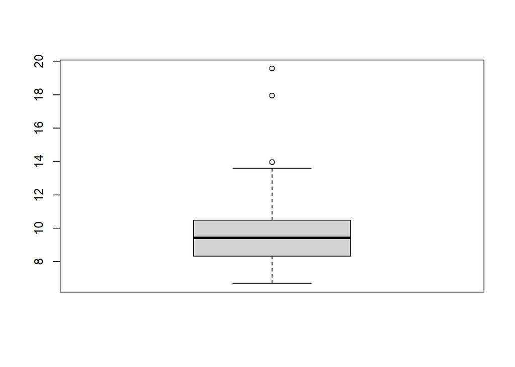

```r
boxplot(data$`Duração da Internação`)
```

- **Idade**

A idade é uma variável quantitativa contínua que representa a idade média dos pacientes de cada hospital. Os resultados das funções mencionadas anteriormente estão descritos a seguir.

|  | Idade |
| --- | --- |
| Mínimo | 38.800000 |
| 1º Quartil | 50.900000 |
| Mediana | 53.200000 |
| Média | 53.231858 |
| 3º Quartil | 56.200000 |
| Máximo | 65.900000 |
| Variância | 19.905940 |
| Desvio Padrão | 4.461607 |

E o *boxplot* da variável é dado por:

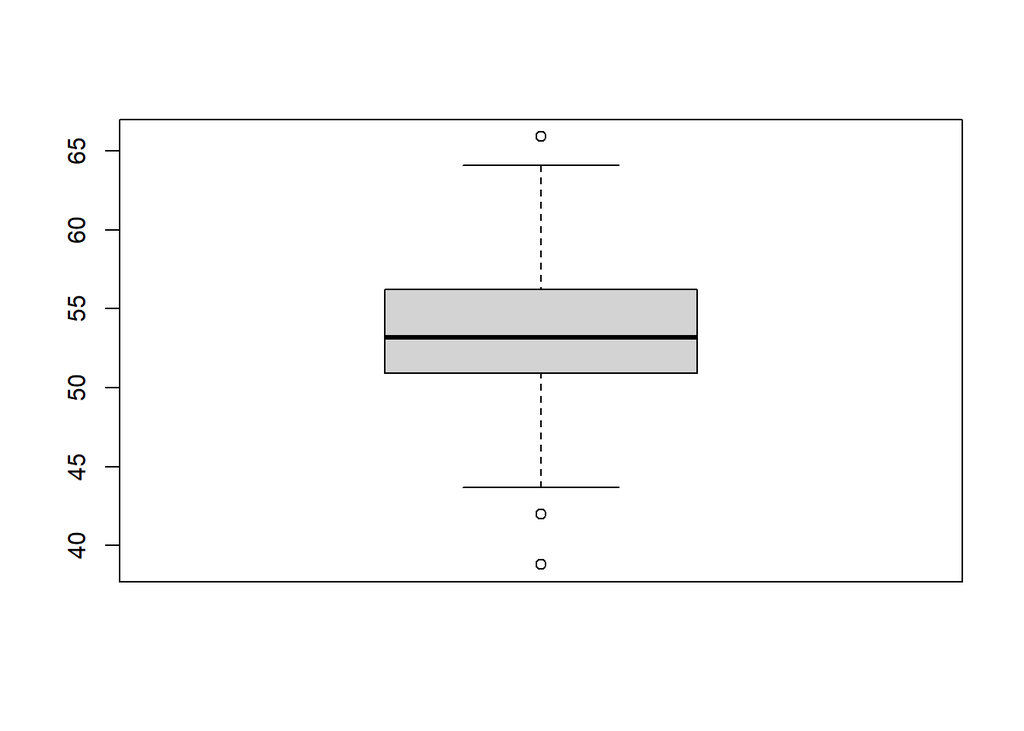

```r
boxplot(data$Idade)
```

- **Risco de Infecção**

O risco de infecção é uma variável quantitativa contínua que representa a probabilidade média estimada de adquirir infecção no hospital (em %). Os resultados das funções mencionadas anteriormente estão descritos a seguir.

|  | Risco de Infecção |
| --- | --- |
| Mínimo | 1.300000 |
| 1º Quartil | 3.700000 |
| Mediana | 4.400000 |
| Média | 4.354867 |
| 3º Quartil | 5.200000 |
| Máximo | 7.800000 |
| Variância | 1.798034 |
| Desvio Padrão | 1.340908 |

E o *boxplot* da variável é dado por:

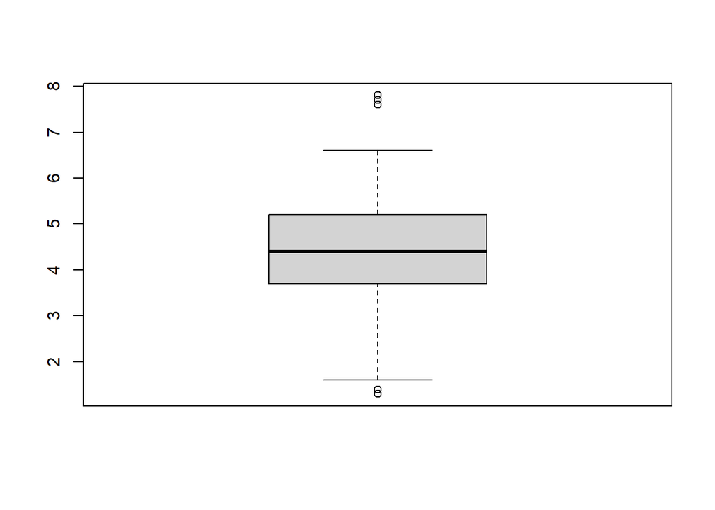

```r
boxplot(data$`Risco de Infecção`)
```

- **Proporção de Culturas de Rotina**

A proporção de culturas de rotina é uma variável quantitativa contínua que representa a razão do número de culturas realizadas com relação ao número de pacientes sem sinais ou sintomas de infeção adquirida no hospital, vezes 100. Os resultados das funções mencionadas anteriormente estão descritos a seguir.

|  | Proporção de Culturas de Rotina |
| --- | --- |
| Mínimo | 1.60000 |
| 1º Quartil | 8.40000 |
| Mediana | 14.10000 |
| Média | 15.79292 |
| 3º Quartil | 20.30000 |
| Máximo | 60.50000 |
| Variância | 104.74924 |
| Desvio Padrão | 10.23471 |

E o *boxplot* da variável é dado por:

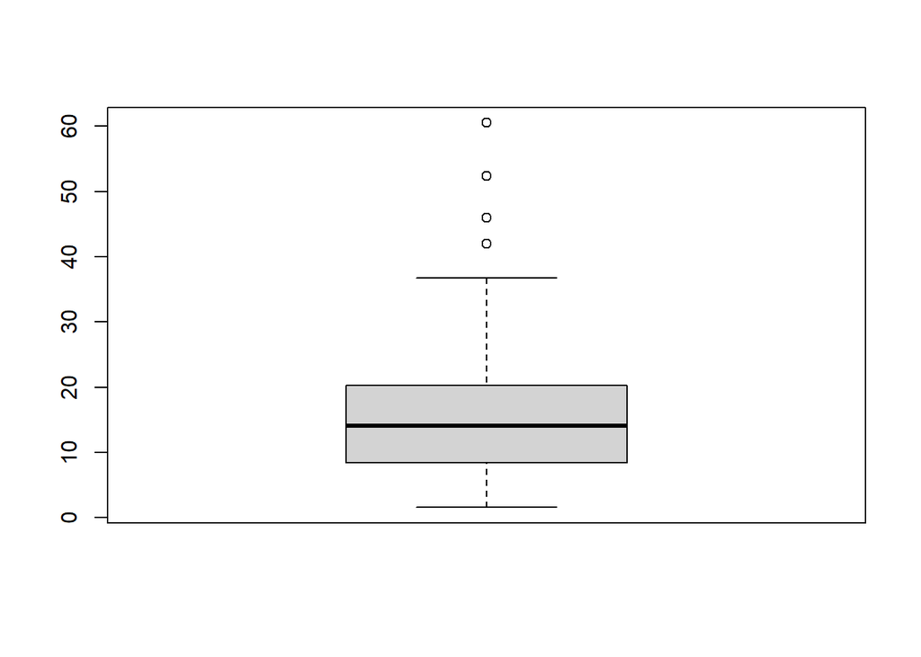

```r
boxplot(data$`Proporção de Culturas de Rotina`)
```

* **Proporção de Raio-X de Tórax de Rotina**

A proporção de raio-X de tórax de rotina é uma variável quantitativa contínua que representa a razão do número de raio-X de tórax realizados com relação ao número de pacientes sem sinais ou sintomas de pneumonia, vezes 100. Os resultados das funções mencionadas anteriormente estão descritos a seguir.

|  | Proporção de Raio-X de Tórax de Rotina |
| --- | --- |
| Mínimo | 39.60000 |
| 1º Quartil | 69.50000 |
| Mediana | 82.30000 |
| Média | 81.62832 |
| 3º Quartil | 94.10000 |
| Máximo | 133.50000 |
| Variância | 374.95776 |
| Desvio Padrão | 19.36383 |

E o *boxplot* da variável é dado por:

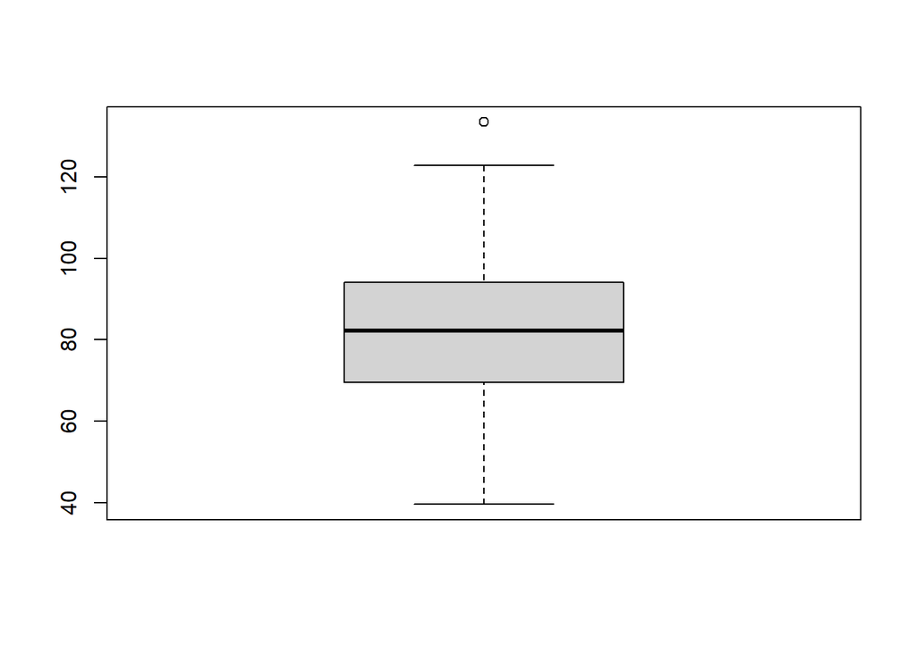

```r
boxplot(data$`Proporção de Raio-X de Tórax de Rotina`)
```

- **Número de leitos**

O número de leitos é uma variável quantitativa discreta que representa o número médio de leitos no hospital durante o período de estudo. Os resultados das funções mencionadas anteriormente estão descritos a seguir.

|  | Número de leitos |
| --- | --- |
| Mínimo | 29.0000 |
| 1º Quartil | 106.0000 |
| Mediana | 186.0000 |
| Média | 252.1681 |
| 3º Quartil | 312.0000 |
| Máximo | 835.0000 |
| Variância | 37188.3018 |
| Desvio Padrão | 192.8427 |

E o *boxplot* da variável é dado por:

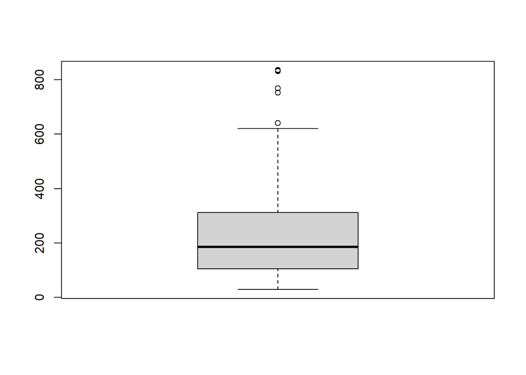

```r
boxplot(data$`Número de leitos`)
```

- **Filiação a Escola de Medicina**

A filiação a escola de medicina é uma variável qualitativa ordinal onde o 1 significa que a escola tem filiação, e 2 que não tem. Os resultados das funções mencionadas anteriormente estão descritos a seguir.

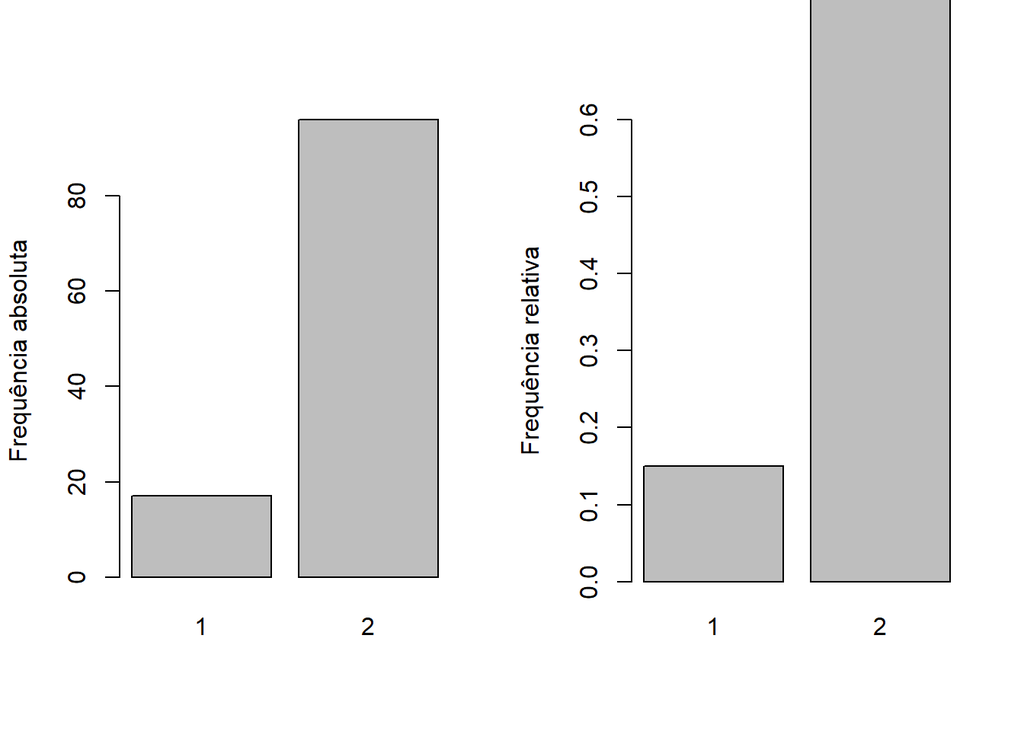

- **Região**

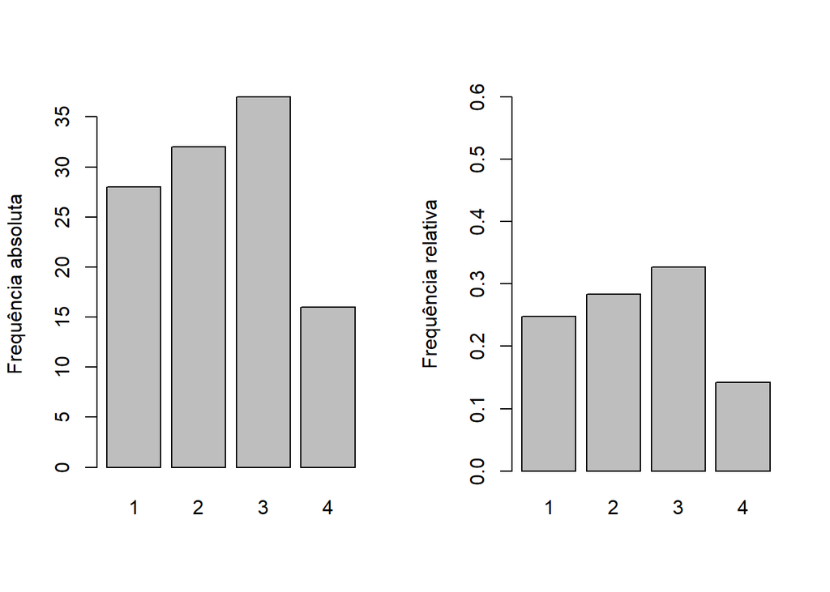

- **Média diária de pacientes**

O média diária de pacientes é uma variável quantitativa discreta que representa o número médio de pacientes no hospital por dia durante o período do estudo. Os resultados das funções mencionadas anteriormente estão descritos a seguir.

|  | Média diária de pacientes |
| --- | --- |
| Mínimo | 20.0000 |
| 1º Quartil | 68.0000 |
| Mediana | 143.0000 |
| Média | 191.3717 |
| 3º Quartil | 252.0000 |
| Máximo | 791.0000 |
| Variância | 23642.0035 |
| Desvio Padrão | 153.7596 |

E o *boxplot* da variável é dado por:

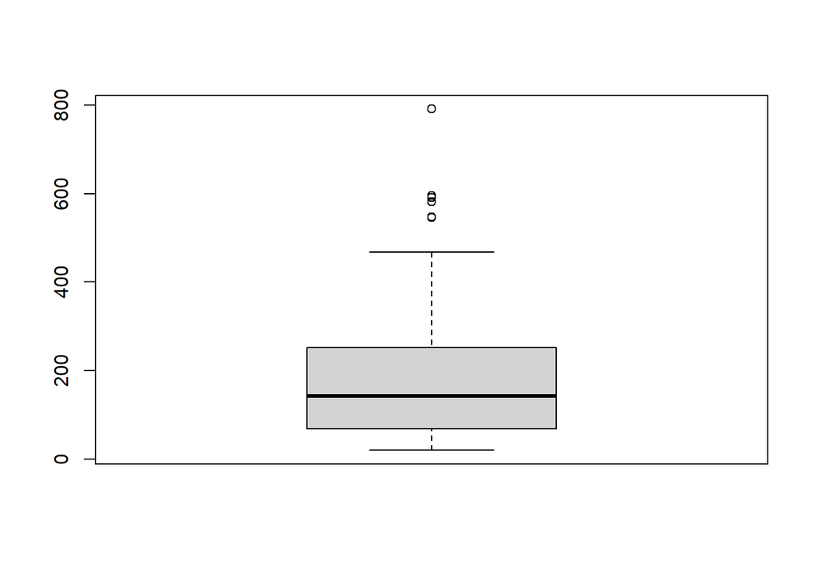

```r
boxplot(data$`Média diária de pacientes`)
```

- **Número de enfermeiro(s)**

O número de enfermeiro(s) é uma variável quantitativa discreta que representa o Número médio de enfermeiros(as) de tempo-integral ou equivalente registrados e licenciados durante o período de estudo (número de tempos integrais+metade do número de tempo parcial). Os resultados das funções mencionadas anteriormente estão descritos a seguir.

|  | Número de enfermeiro(s) |
| --- | --- |
| Mínimo | 14.0000 |
| 1º Quartil | 66.0000 |
| Mediana | 132.0000 |
| Média | 173.2478 |
| 3º Quartil | 218.0000 |
| Máximo | 656.0000 |
| Variância | 19394.8488 |
| Desvio Padrão | 139.2654 |

E o *boxplot* da variável é dado por:

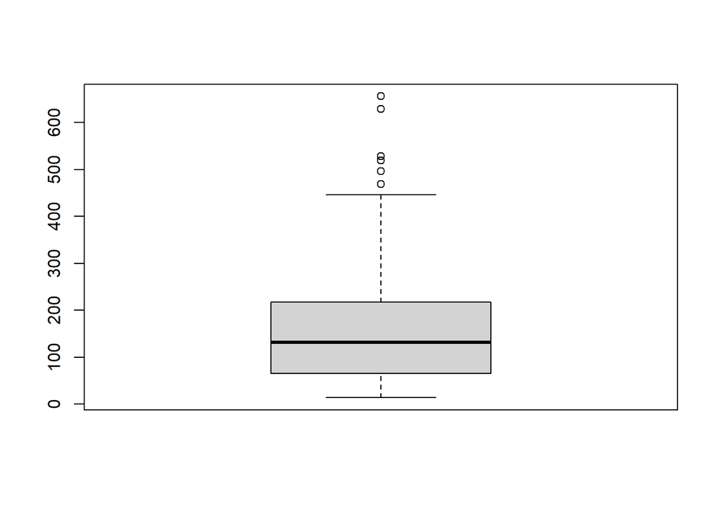

```r
boxplot(data$`Número de enfermeiro(s)`)
```

- **Facilidades e serviços disponíveis**

A facilidades e serviços disponíveis é uma variável quantitativa contínua que representa a porcentagem de 35 potenciais facilidades e serviços que são fornecidos pelo hospital. Os resultados das funções mencionadas anteriormente estão descritos a seguir.

|  | Facilidades e serviços disponíveis |
| --- | --- |
| Mínimo | 5.70000 |
| 1º Quartil | 31.40000 |
| Mediana | 42.90000 |
| Média | 43.15929 |
| 3º Quartil | 54.30000 |
| Máximo | 80.00000 |
| Variância | 231.06619 |
| Desvio Padrão | 15.20086 |

E o *boxplot* da variável é dado por:

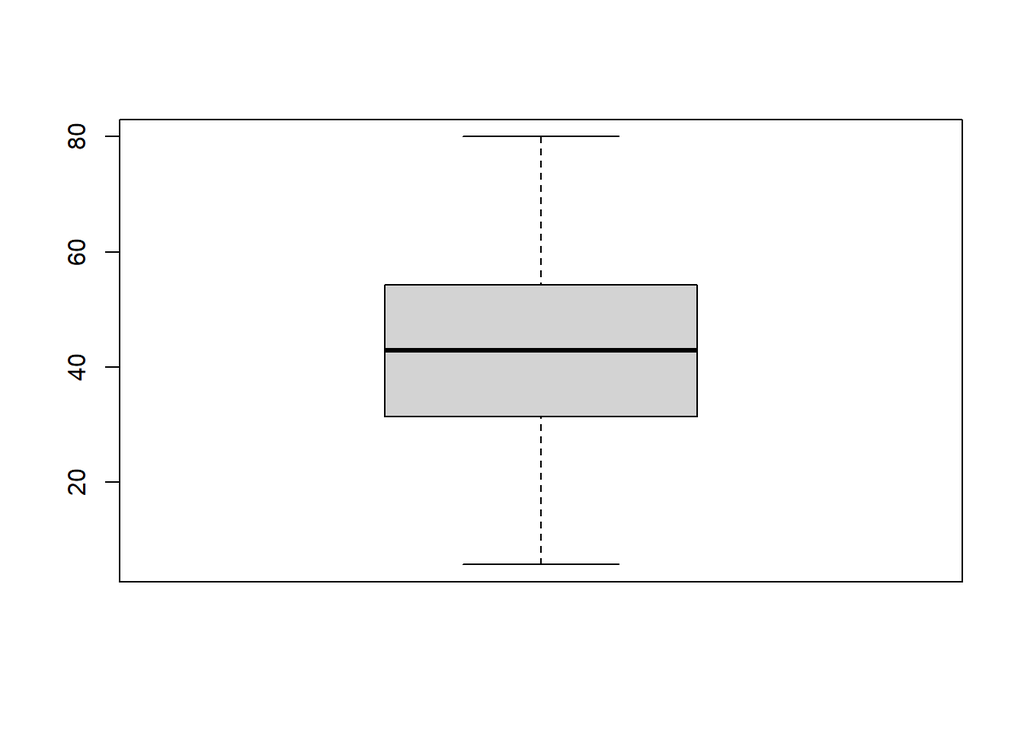

```r
boxplot(data$`Facilidades e serviços disponíveis`)
```

### Correlação entre as variáveis

Para verificar a natureza e a força da relação entre as variáveis e identificar lacunas e pontos discrepantes no conjunto de dados, utiliza-se a matriz de correlação aplicado no script a seguir.

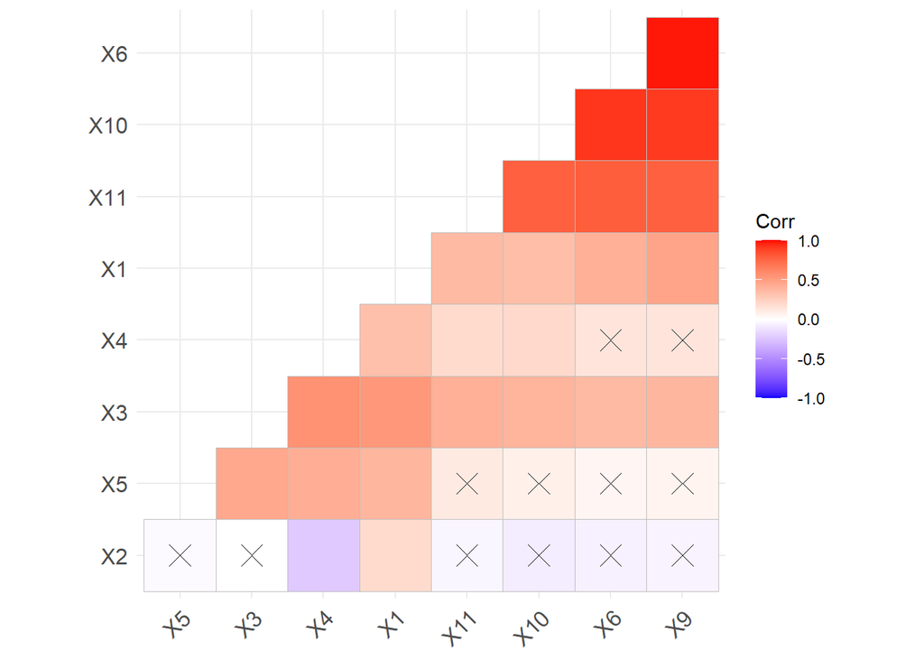

```r
library(ggcorrplot)
library(dplyr)
pmat = datax %>% select_if(is.numeric) %>%cor_pmat()

datax %>% select_if(is.numeric) %>% cor(.) %>%
  ggcorrplot( type = "lower", p.mat = pmat, hc.order = TRUE)
```

```r
knitr::kable(cbind(names(data),names(datax)))
```

| Número de Identificação | ID |
| --- | --- |
| Duração da Internação | X1 |
| Idade | X2 |
| Risco de Infecção | X3 |
| Proporção de Culturas de Rotina | X4 |
| Proporção de Raio-X de Tórax de Rotina | X5 |
| Número de leitos | X6 |
| Filiação a Escola de Medicina | X7 |
| Região | X8 |
| Média diária de pacientes | X9 |
| Número de enfermeiro(s) | X10 |
| Facilidades e serviços disponíveis | X11 |

nesta matriz, percebe-se que quanto mais vermelho, maior é a correlação positiva, no qual as variável de facilidades e serviços disponiveis está positivamente correlacionada com o número de enfermeiro(s), número de leitos e a média diaria de pacientes. Para o número de leitos, há uma alta correlação positiva com a média diária depacientes.

Para verificar a ausência significativa de correlação, o teste de ausência de correlação com nível de significância de 5%, no gráfico acima, temos que as variáveis que são marcadas com X, o teste não foi significante, indicando independência entre estas variáveis, entre elas, a idade do paciente, não tem correlação com o risco de infeção do hospital.

# Objetivo

## Número de enfermeira(o)s

Deseja-se estudar se o número de enfermeira(o)s está relacionado às instalações, ou seja, os números de leitos do hospital, e se há diferenças entre os serviços disponíveis pelos hospitais. Neste caso, a variável resposta é o número de enfermeira(o)s e as duas outras variáveis são explicativas. Para isso, faz-se necessário a aplicação da regressão linear múltipla realizada no script a seguir:

```r
# teste de ausencia de regresao (significativo)
summary(aov(`Número de enfermeiro(s)` ~ `Número de leitos`+ `Facilidades e serviços disponíveis`, data=data))
```

```
##                                       Df  Sum Sq Mean Sq F value Pr(>F)
## `Número de leitos`                     1 1820644 1820644 601.362 <2e-16 ***
## `Facilidades e serviços disponíveis`   1   18550   18550   6.127 0.0148 *
## Residuals                            110  333029    3028
## ---
## Signif. codes:  0 '***' 0.001 '**' 0.01 '*' 0.05 '.' 0.1 ' ' 1
```

```r
modcomp<-lm(`Número de enfermeiro(s)` ~ `Número de leitos` +
              I(`Número de leitos`^2)+
              `Facilidades e serviços disponíveis`+
              I(`Facilidades e serviços disponíveis`^2)+
              `Facilidades e serviços disponíveis`*`Número de leitos`
              , data = data)

summary(modcomp)
```

```
##
## Call:
## lm(formula = `Número de enfermeiro(s)` ~ `Número de leitos` +
##     I(`Número de leitos`^2) + `Facilidades e serviços disponíveis` +
##     I(`Facilidades e serviços disponíveis`^2) + `Facilidades e serviços disponíveis` *
##     `Número de leitos`, data = data)
##
## Residuals:
##      Min       1Q   Median       3Q      Max
## -162.973  -24.758   -2.339   21.880  210.964
##
## Coefficients:
##                                                           Estimate Std. Error
## (Intercept)                                             -3.125e+01  3.698e+01
## `Número de leitos`                                       4.217e-01  2.023e-01
## I(`Número de leitos`^2)                                 -5.006e-04  2.686e-04
## `Facilidades e serviços disponíveis`                     2.212e+00  2.350e+00
## I(`Facilidades e serviços disponíveis`^2)               -3.646e-02  3.770e-02
## `Número de leitos`:`Facilidades e serviços disponíveis`  9.797e-03  5.920e-03
##                                                         t value Pr(>|t|)
## (Intercept)                                              -0.845   0.3999
## `Número de leitos`                                        2.084   0.0395 *
## I(`Número de leitos`^2)                                  -1.864   0.0651 .
## `Facilidades e serviços disponíveis`                      0.941   0.3486
## I(`Facilidades e serviços disponíveis`^2)                -0.967   0.3356
## `Número de leitos`:`Facilidades e serviços disponíveis`   1.655   0.1009
## ---
## Signif. codes:  0 '***' 0.001 '**' 0.01 '*' 0.05 '.' 0.1 ' ' 1
##
## Residual standard error: 54.89 on 107 degrees of freedom
## Multiple R-squared:  0.8516, Adjusted R-squared:  0.8447
## F-statistic: 122.8 on 5 and 107 DF,  p-value: < 2.2e-16
```

```r
shapiro.test(residuals(modcomp))
```

```
##
##  Shapiro-Wilk normality test
##
## data:  residuals(modcomp)
## W = 0.94595, p-value = 0.0001791
```

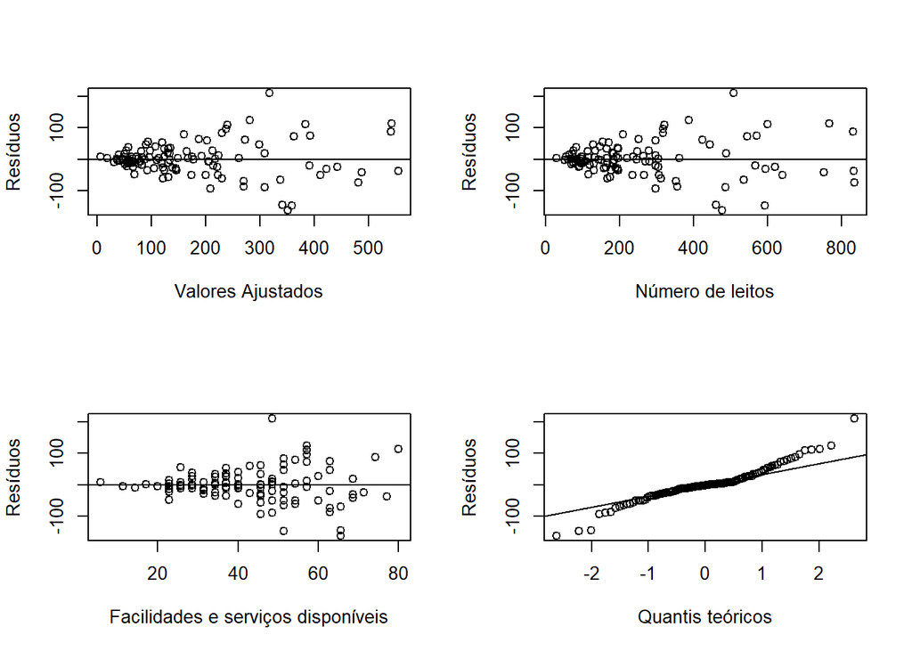

```r
# windows()
par(mfrow = c(2, 2))
plot(fitted(modcomp), residuals(modcomp),xlab="Valores Ajustados",ylab="Resíduos")
abline(h=0)
plot(data$`Número de leitos`, residuals(modcomp),xlab="Número de leitos",ylab="Resíduos")
abline(h=0)

plot(data$`Facilidades e serviços disponíveis`, residuals(modcomp),xlab="Facilidades e serviços disponíveis",ylab="Resíduos")
abline(h=0)

qqnorm(residuals(modcomp), ylab="Resíduos",xlab="Quantis teóricos",main="")
qqline(residuals(modcomp))
```

```r
# Teste de ausencia de regressao
summary(aov(`Duração da Internação` ~
              `Proporção de Raio-X de Tórax de Rotina`+
              `Proporção de Culturas de Rotina`,
            data = data))
```

```
##                                           Df Sum Sq Mean Sq F value   Pr(>F)
## `Proporção de Raio-X de Tórax de Rotina`   1   59.9   59.86  19.605 2.26e-05
## `Proporção de Culturas de Rotina`          1   13.5   13.46   4.406   0.0381
## Residuals                                110  335.9    3.05
##
## `Proporção de Raio-X de Tórax de Rotina` ***
## `Proporção de Culturas de Rotina`        *
## Residuals
## ---
## Signif. codes:  0 '***' 0.001 '**' 0.01 '*' 0.05 '.' 0.1 ' ' 1
```

```r
# Regressao
modcomp<-lm(`Duração da Internação` ~
              `Proporção de Raio-X de Tórax de Rotina`+
              `Proporção de Culturas de Rotina`,
            data = data)
summary(modcomp)
```

```
##
## Call:
## lm(formula = `Duração da Internação` ~ `Proporção de Raio-X de Tórax de Rotina` +
##     `Proporção de Culturas de Rotina`, data = data)
##
## Residuals:
##     Min      1Q  Median      3Q     Max
## -2.8987 -1.0846 -0.2387  0.6384  8.9177
##
## Coefficients:
##                                          Estimate Std. Error t value Pr(>|t|)
## (Intercept)                               6.66147    0.71664   9.295 1.61e-15
## `Proporção de Raio-X de Tórax de Rotina`  0.02935    0.00942   3.116  0.00234
## `Proporção de Culturas de Rotina`         0.03741    0.01782   2.099  0.03809
##
## (Intercept)                              ***
## `Proporção de Raio-X de Tórax de Rotina` **
## `Proporção de Culturas de Rotina`        *
## ---
## Signif. codes:  0 '***' 0.001 '**' 0.01 '*' 0.05 '.' 0.1 ' ' 1
##
## Residual standard error: 1.747 on 110 degrees of freedom
## Multiple R-squared:  0.1792, Adjusted R-squared:  0.1642
## F-statistic: 12.01 on 2 and 110 DF,  p-value: 1.922e-05
```

```r
# Teste de normalidade
shapiro.test(residuals(modcomp))
```

```
##
##  Shapiro-Wilk normality test
##
## data:  residuals(modcomp)
## W = 0.86649, p-value = 1.146e-08
```

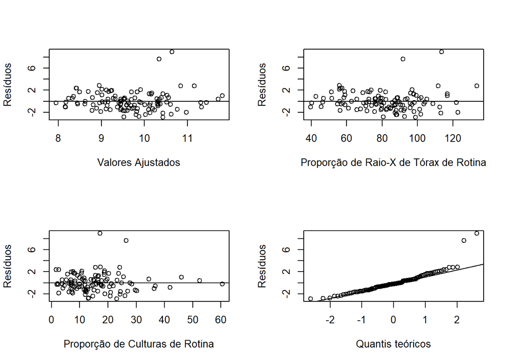

```r
# bartlett.test(residuals(modcomp))



# windows()
par(mfrow = c(2, 2))
plot(fitted(modcomp), residuals(modcomp),xlab="Valores Ajustados",ylab="Resíduos")
abline(h=0)
plot(data$`Proporção de Raio-X de Tórax de Rotina`, residuals(modcomp),xlab="Proporção de Raio-X de Tórax de Rotina",ylab="Resíduos")
abline(h=0)

plot(data$`Proporção de Culturas de Rotina`, residuals(modcomp),xlab="Proporção de Culturas de Rotina",ylab="Resíduos")
abline(h=0)

qqnorm(residuals(modcomp), ylab="Resíduos",xlab="Quantis teóricos",main="")
qqline(residuals(modcomp))
```